# Risk Factor Analysis

## Outcome Variable

**Outcome Variable:** haz

## Predictor Variables

**Intervention Variable:** hfoodsec

**Adjustment Set:**

unadjusted

## Stratifying Variables

The analysis was stratified on these variable(s):

- agecat
- studyid
- country

## Data Summary

| agecat | studyid | country | hfoodsec | n_cell | n |
| --- | --- | --- | --- | --- | --- |
| Birth | GMS-Nepal | NEPAL | Food Secure | 477 | 672 |
| Birth | GMS-Nepal | NEPAL | Mildly Food Insecure | 106 | 672 |
| Birth | GMS-Nepal | NEPAL | Food Insecure | 89 | 672 |
| Birth | MAL-ED | BANGLADESH | Food Secure | 144 | 172 |
| Birth | MAL-ED | BANGLADESH | Mildly Food Insecure | 4 | 172 |
| Birth | MAL-ED | BANGLADESH | Food Insecure | 24 | 172 |
| Birth | MAL-ED | BRAZIL | Food Secure | 0 | 28 |
| Birth | MAL-ED | BRAZIL | Mildly Food Insecure | 4 | 28 |
| Birth | MAL-ED | BRAZIL | Food Insecure | 24 | 28 |
| Birth | MAL-ED | INDIA | Food Secure | 34 | 37 |
| Birth | MAL-ED | INDIA | Mildly Food Insecure | 1 | 37 |
| Birth | MAL-ED | INDIA | Food Insecure | 2 | 37 |
| Birth | MAL-ED | NEPAL | Food Secure | 10 | 14 |
| Birth | MAL-ED | NEPAL | Mildly Food Insecure | 1 | 14 |
| Birth | MAL-ED | NEPAL | Food Insecure | 3 | 14 |
| Birth | MAL-ED | PERU | Food Secure | 24 | 91 |
| Birth | MAL-ED | PERU | Mildly Food Insecure | 23 | 91 |
| Birth | MAL-ED | PERU | Food Insecure | 44 | 91 |
| Birth | MAL-ED | SOUTH AFRICA | Food Secure | 45 | 88 |
| Birth | MAL-ED | SOUTH AFRICA | Mildly Food Insecure | 9 | 88 |
| Birth | MAL-ED | SOUTH AFRICA | Food Insecure | 34 | 88 |
| Birth | NIH-Birth | BANGLADESH | Food Secure | 90 | 608 |
| Birth | NIH-Birth | BANGLADESH | Mildly Food Insecure | 478 | 608 |
| Birth | NIH-Birth | BANGLADESH | Food Insecure | 40 | 608 |
| Birth | NIH-Crypto | BANGLADESH | Food Secure | 439 | 732 |
| Birth | NIH-Crypto | BANGLADESH | Mildly Food Insecure | 209 | 732 |
| Birth | NIH-Crypto | BANGLADESH | Food Insecure | 84 | 732 |
| 6 months | GMS-Nepal | NEPAL | Food Secure | 396 | 546 |
| 6 months | GMS-Nepal | NEPAL | Mildly Food Insecure | 76 | 546 |
| 6 months | GMS-Nepal | NEPAL | Food Insecure | 74 | 546 |

[output cut: 51 more lines]

The following strata were considered:

- agecat: 24 months, studyid: GMS-Nepal, country: NEPAL
- agecat: 24 months, studyid: MAL-ED, country: BANGLADESH
- agecat: 24 months, studyid: MAL-ED, country: BRAZIL
- agecat: 24 months, studyid: MAL-ED, country: INDIA
- agecat: 24 months, studyid: MAL-ED, country: NEPAL
- agecat: 24 months, studyid: MAL-ED, country: PERU
- agecat: 24 months, studyid: MAL-ED, country: SOUTH AFRICA
- agecat: 24 months, studyid: NIH-Birth, country: BANGLADESH
- agecat: 24 months, studyid: NIH-Crypto, country: BANGLADESH
- agecat: 6 months, studyid: GMS-Nepal, country: NEPAL
- agecat: 6 months, studyid: MAL-ED, country: BANGLADESH
- agecat: 6 months, studyid: MAL-ED, country: BRAZIL
- agecat: 6 months, studyid: MAL-ED, country: INDIA
- agecat: 6 months, studyid: MAL-ED, country: NEPAL
- agecat: 6 months, studyid: MAL-ED, country: PERU
- agecat: 6 months, studyid: MAL-ED, country: SOUTH AFRICA
- agecat: 6 months, studyid: NIH-Birth, country: BANGLADESH
- agecat: 6 months, studyid: NIH-Crypto, country: BANGLADESH
- agecat: Birth, studyid: GMS-Nepal, country: NEPAL
- agecat: Birth, studyid: MAL-ED, country: BANGLADESH
- agecat: Birth, studyid: MAL-ED, country: BRAZIL
- agecat: Birth, studyid: MAL-ED, country: INDIA
- agecat: Birth, studyid: MAL-ED, country: NEPAL
- agecat: Birth, studyid: MAL-ED, country: PERU
- agecat: Birth, studyid: MAL-ED, country: SOUTH AFRICA
- agecat: Birth, studyid: NIH-Birth, country: BANGLADESH
- agecat: Birth, studyid: NIH-Crypto, country: BANGLADESH

### Dropped Strata

Some strata were dropped due to rare outcomes:

- agecat: Birth, studyid: MAL-ED, country: BANGLADESH
- agecat: Birth, studyid: MAL-ED, country: BRAZIL
- agecat: Birth, studyid: MAL-ED, country: INDIA
- agecat: Birth, studyid: MAL-ED, country: NEPAL
- agecat: 6 months, studyid: MAL-ED, country: BANGLADESH
- agecat: 6 months, studyid: MAL-ED, country: BRAZIL
- agecat: 24 months, studyid: MAL-ED, country: BANGLADESH
- agecat: 24 months, studyid: MAL-ED, country: BRAZIL

## Methods Detail

We’re interested in the causal parameters $E[Y_a]$ for all values of $a \in \mathcal{A}$. These parameters represent the mean outcome if, possibly contrary to fact, we intervened to set all units to have $A=a$. Under the randomization and positivity assumptions, these are identified by the statistical parameters $\psi_a=E_W[E_{Y|A,W}(Y|A=a,W)]$. In addition, we’re interested in the mean of $Y$, $E[Y]$ under no intervention (the observed mean). We will estimate these parameters by using SuperLearner to fit the relevant likelihood factors – $E_{Y|A,W}(Y|A=a,W)$ and $p(A=a|W)$, and then updating our likelihood fit using a joint TMLE.

For unadjusted analyses ($W=\{\}$), initial likelihoods were estimated using Lrnr_glm to estimate the simple $E(Y|A)$ and Lrnr_mean to estimate $p(A)$. For adjusted analyses, a small library containing Lrnr_glmnet, Lrnr_xgboost, and Lrnr_mean was used.

Having estimated these parameters, we will then use the delta method to estimate relative risks and attributable risks relative to a prespecified baseline level of $A$.

# Results Detail

## Results Plots

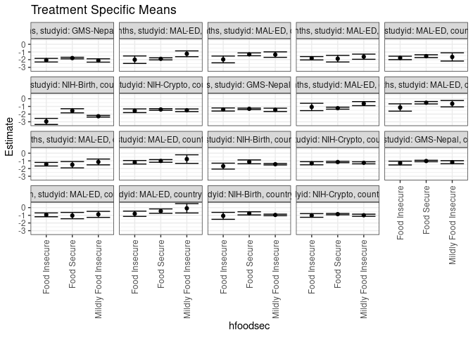

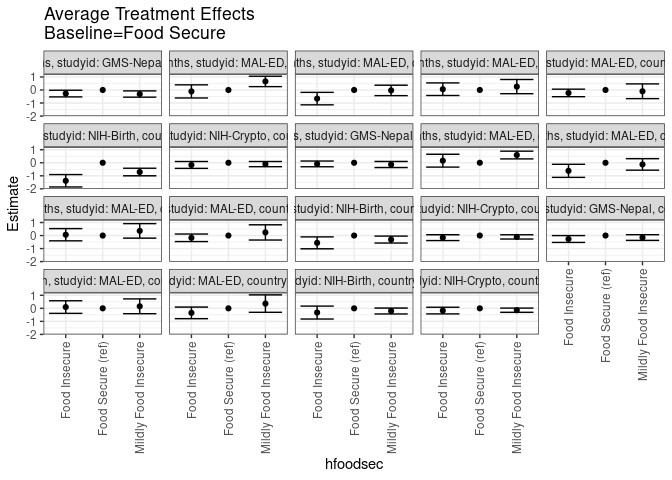

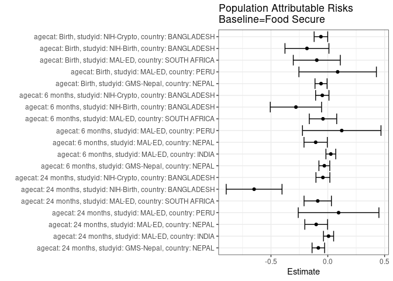

## Results Table

### Parameter: TSM

| agecat | studyid | country | intervention_level | baseline_level | estimate | ci_lower | ci_upper |
| --- | --- | --- | --- | --- | --- | --- | --- |
| Birth | GMS-Nepal | NEPAL | Food Secure | NA | -1.0198323 | -1.1147037 | -0.9249609 |
| Birth | GMS-Nepal | NEPAL | Mildly Food Insecure | NA | -1.1733962 | -1.3699984 | -0.9767941 |
| Birth | GMS-Nepal | NEPAL | Food Insecure | NA | -1.2851685 | -1.5305036 | -1.0398335 |
| Birth | MAL-ED | PERU | Food Secure | NA | -1.0358333 | -1.4468365 | -0.6248301 |
| Birth | MAL-ED | PERU | Mildly Food Insecure | NA | -0.8791304 | -1.2697827 | -0.4884782 |
| Birth | MAL-ED | PERU | Food Insecure | NA | -0.9381818 | -1.1902133 | -0.6861503 |
| Birth | MAL-ED | SOUTH AFRICA | Food Secure | NA | -0.4535556 | -0.7370575 | -0.1700536 |
| Birth | MAL-ED | SOUTH AFRICA | Mildly Food Insecure | NA | -0.0888889 | -0.6955550 | 0.5177773 |
| Birth | MAL-ED | SOUTH AFRICA | Food Insecure | NA | -0.8005882 | -1.1433809 | -0.4577955 |
| Birth | NIH-Birth | BANGLADESH | Food Secure | NA | -0.7476667 | -0.9526135 | -0.5427198 |
| Birth | NIH-Birth | BANGLADESH | Mildly Food Insecure | NA | -0.9538075 | -1.0525090 | -0.8551061 |
| Birth | NIH-Birth | BANGLADESH | Food Insecure | NA | -1.0712500 | -1.5239779 | -0.6185221 |
| Birth | NIH-Crypto | BANGLADESH | Food Secure | NA | -0.8490433 | -0.9366509 | -0.7614356 |
| Birth | NIH-Crypto | BANGLADESH | Mildly Food Insecure | NA | -0.9926316 | -1.1307404 | -0.8545227 |
| Birth | NIH-Crypto | BANGLADESH | Food Insecure | NA | -1.0185714 | -1.2587297 | -0.7784132 |
| 6 months | GMS-Nepal | NEPAL | Food Secure | NA | -1.3118140 | -1.4036500 | -1.2199779 |
| 6 months | GMS-Nepal | NEPAL | Mildly Food Insecure | NA | -1.4443421 | -1.6584481 | -1.2302362 |
| 6 months | GMS-Nepal | NEPAL | Food Insecure | NA | -1.3997297 | -1.5991754 | -1.2002841 |
| 6 months | MAL-ED | INDIA | Food Secure | NA | -1.2287544 | -1.3589893 | -1.0985195 |
| 6 months | MAL-ED | INDIA | Mildly Food Insecure | NA | -0.6360000 | -0.9019405 | -0.3700595 |
| 6 months | MAL-ED | INDIA | Food Insecure | NA | -1.0694118 | -1.5456747 | -0.5931488 |
| 6 months | MAL-ED | NEPAL | Food Secure | NA | -0.5194681 | -0.6784051 | -0.3605311 |
| 6 months | MAL-ED | NEPAL | Mildly Food Insecure | NA | -0.6463333 | -1.0577510 | -0.2349156 |
| 6 months | MAL-ED | NEPAL | Food Insecure | NA | -1.1388596 | -1.6144149 | -0.6633044 |
| 6 months | MAL-ED | PERU | Food Secure | NA | -1.5010494 | -1.9103743 | -1.0917244 |
| 6 months | MAL-ED | PERU | Mildly Food Insecure | NA | -1.1423214 | -1.5197567 | -0.7648862 |
| 6 months | MAL-ED | PERU | Food Insecure | NA | -1.4372619 | -1.6697518 | -1.2047720 |
| 6 months | MAL-ED | SOUTH AFRICA | Food Secure | NA | -1.0117700 | -1.1866003 | -0.8369397 |
| 6 months | MAL-ED | SOUTH AFRICA | Mildly Food Insecure | NA | -0.7707407 | -1.3286896 | -0.2127919 |
| 6 months | MAL-ED | SOUTH AFRICA | Food Insecure | NA | -1.1839918 | -1.4133758 | -0.9546077 |
| 6 months | NIH-Birth | BANGLADESH | Food Secure | NA | -1.1268542 | -1.3747544 | -0.8789539 |
| 6 months | NIH-Birth | BANGLADESH | Mildly Food Insecure | NA | -1.4343905 | -1.5303921 | -1.3383889 |
| 6 months | NIH-Birth | BANGLADESH | Food Insecure | NA | -1.6868750 | -2.0695528 | -1.3041972 |
| 6 months | NIH-Crypto | BANGLADESH | Food Secure | NA | -1.1502927 | -1.2422659 | -1.0583196 |
| 6 months | NIH-Crypto | BANGLADESH | Mildly Food Insecure | NA | -1.2534804 | -1.3885153 | -1.1184455 |
| 6 months | NIH-Crypto | BANGLADESH | Food Insecure | NA | -1.3115476 | -1.5163063 | -1.1067890 |
| 24 months | GMS-Nepal | NEPAL | Food Secure | NA | -1.7925731 | -1.8940179 | -1.6911283 |
| 24 months | GMS-Nepal | NEPAL | Mildly Food Insecure | NA | -2.1037313 | -2.3208239 | -1.8866388 |
| 24 months | GMS-Nepal | NEPAL | Food Insecure | NA | -2.0672464 | -2.3018311 | -1.8326616 |
| 24 months | MAL-ED | INDIA | Food Secure | NA | -1.8935000 | -2.0301943 | -1.7568057 |
| 24 months | MAL-ED | INDIA | Mildly Food Insecure | NA | -1.2370000 | -1.6132318 | -0.8607682 |
| 24 months | MAL-ED | INDIA | Food Insecure | NA | -2.0035294 | -2.4884028 | -1.5186561 |
| 24 months | MAL-ED | NEPAL | Food Secure | NA | -1.3070745 | -1.4908772 | -1.1232718 |
| 24 months | MAL-ED | NEPAL | Mildly Food Insecure | NA | -1.3400000 | -1.6955726 | -0.9844274 |
| 24 months | MAL-ED | NEPAL | Food Insecure | NA | -1.9692105 | -2.4098511 | -1.5285700 |
| 24 months | MAL-ED | PERU | Food Secure | NA | -1.8733974 | -2.3040404 | -1.4427545 |
| 24 months | MAL-ED | PERU | Mildly Food Insecure | NA | -1.6153086 | -1.9500077 | -1.2806096 |
| 24 months | MAL-ED | PERU | Food Insecure | NA | -1.8141975 | -2.0338833 | -1.5945118 |
| 24 months | MAL-ED | SOUTH AFRICA | Food Secure | NA | -1.5446318 | -1.7266755 | -1.3625881 |
| 24 months | MAL-ED | SOUTH AFRICA | Mildly Food Insecure | NA | -1.6427778 | -2.1783248 | -1.1072307 |
| 24 months | MAL-ED | SOUTH AFRICA | Food Insecure | NA | -1.7719342 | -1.9948623 | -1.5490060 |
| 24 months | NIH-Birth | BANGLADESH | Food Secure | NA | -1.5704412 | -1.8406299 | -1.3002524 |
| 24 months | NIH-Birth | BANGLADESH | Mildly Food Insecure | NA | -2.2797104 | -2.3875556 | -2.1718651 |
| 24 months | NIH-Birth | BANGLADESH | Food Insecure | NA | -2.9527525 | -3.3462898 | -2.5592153 |
| 24 months | NIH-Crypto | BANGLADESH | Food Secure | NA | -1.3982635 | -1.5024958 | -1.2940312 |
| 24 months | NIH-Crypto | BANGLADESH | Mildly Food Insecure | NA | -1.5015323 | -1.6719320 | -1.3311325 |
| 24 months | NIH-Crypto | BANGLADESH | Food Insecure | NA | -1.5642857 | -1.8057828 | -1.3227886 |

### Parameter: E(Y)

| agecat | studyid | country | intervention_level | baseline_level | estimate | ci_lower | ci_upper |
| --- | --- | --- | --- | --- | --- | --- | --- |
| Birth | GMS-Nepal | NEPAL | NA | NA | -1.0791964 | -1.1604792 | -0.9979137 |
| Birth | MAL-ED | PERU | NA | NA | -0.9490110 | -1.1400314 | -0.7579906 |
| Birth | MAL-ED | SOUTH AFRICA | NA | NA | -0.5503409 | -0.7616444 | -0.3390374 |
| Birth | NIH-Birth | BANGLADESH | NA | NA | -0.9310197 | -1.0197391 | -0.8423003 |
| Birth | NIH-Crypto | BANGLADESH | NA | NA | -0.9094945 | -0.9809370 | -0.8380521 |
| 6 months | GMS-Nepal | NEPAL | NA | NA | -1.3421764 | -1.4201083 | -1.2642445 |
| 6 months | MAL-ED | INDIA | NA | NA | -1.2019969 | -1.3256948 | -1.0782989 |
| 6 months | MAL-ED | NEPAL | NA | NA | -0.6262760 | -0.7758267 | -0.4767254 |
| 6 months | MAL-ED | PERU | NA | NA | -1.3783784 | -1.5611768 | -1.1955799 |
| 6 months | MAL-ED | SOUTH AFRICA | NA | NA | -1.0539254 | -1.1902766 | -0.9175743 |
| 6 months | NIH-Birth | BANGLADESH | NA | NA | -1.4073821 | -1.4960598 | -1.3187043 |
| 6 months | NIH-Crypto | BANGLADESH | NA | NA | -1.1986783 | -1.2700937 | -1.1272630 |
| 24 months | GMS-Nepal | NEPAL | NA | NA | -1.8758368 | -1.9623349 | -1.7893388 |
| 24 months | MAL-ED | INDIA | NA | NA | -1.8868396 | -2.0164954 | -1.7571839 |
| 24 months | MAL-ED | NEPAL | NA | NA | -1.4092187 | -1.5701249 | -1.2483126 |
| 24 months | MAL-ED | PERU | NA | NA | -1.7783956 | -1.9536701 | -1.6031212 |
| 24 months | MAL-ED | SOUTH AFRICA | NA | NA | -1.6331323 | -1.7704624 | -1.4958022 |
| 24 months | NIH-Birth | BANGLADESH | NA | NA | -2.2190579 | -2.3217459 | -2.1163699 |
| 24 months | NIH-Crypto | BANGLADESH | NA | NA | -1.4412646 | -1.5249156 | -1.3576135 |

### Parameter: ATE

| agecat | studyid | country | intervention_level | baseline_level | estimate | ci_lower | ci_upper |
| --- | --- | --- | --- | --- | --- | --- | --- |
| Birth | GMS-Nepal | NEPAL | Food Secure | Food Secure | 0.0000000 | 0.0000000 | 0.0000000 |
| Birth | GMS-Nepal | NEPAL | Mildly Food Insecure | Food Secure | -0.1535639 | -0.3718596 | 0.0647317 |
| Birth | GMS-Nepal | NEPAL | Food Insecure | Food Secure | -0.2653363 | -0.5283759 | -0.0022966 |
| Birth | MAL-ED | PERU | Food Secure | Food Secure | 0.0000000 | 0.0000000 | 0.0000000 |
| Birth | MAL-ED | PERU | Mildly Food Insecure | Food Secure | 0.1567029 | -0.4103358 | 0.7237415 |
| Birth | MAL-ED | PERU | Food Insecure | Food Secure | 0.0976515 | -0.3844724 | 0.5797755 |
| Birth | MAL-ED | SOUTH AFRICA | Food Secure | Food Secure | 0.0000000 | 0.0000000 | 0.0000000 |
| Birth | MAL-ED | SOUTH AFRICA | Mildly Food Insecure | Food Secure | 0.3646667 | -0.3049729 | 1.0343063 |
| Birth | MAL-ED | SOUTH AFRICA | Food Insecure | Food Secure | -0.3470327 | -0.7918699 | 0.0978046 |
| Birth | NIH-Birth | BANGLADESH | Food Secure | Food Secure | 0.0000000 | 0.0000000 | 0.0000000 |
| Birth | NIH-Birth | BANGLADESH | Mildly Food Insecure | Food Secure | -0.2061409 | -0.4336165 | 0.0213348 |
| Birth | NIH-Birth | BANGLADESH | Food Insecure | Food Secure | -0.3235833 | -0.8205399 | 0.1733732 |
| Birth | NIH-Crypto | BANGLADESH | Food Secure | Food Secure | 0.0000000 | 0.0000000 | 0.0000000 |
| Birth | NIH-Crypto | BANGLADESH | Mildly Food Insecure | Food Secure | -0.1435883 | -0.3071400 | 0.0199634 |
| Birth | NIH-Crypto | BANGLADESH | Food Insecure | Food Secure | -0.1695281 | -0.4251667 | 0.0861104 |
| 6 months | GMS-Nepal | NEPAL | Food Secure | Food Secure | 0.0000000 | 0.0000000 | 0.0000000 |
| 6 months | GMS-Nepal | NEPAL | Mildly Food Insecure | Food Secure | -0.1325281 | -0.3654986 | 0.1004423 |
| 6 months | GMS-Nepal | NEPAL | Food Insecure | Food Secure | -0.0879158 | -0.3074890 | 0.1316575 |
| 6 months | MAL-ED | INDIA | Food Secure | Food Secure | 0.0000000 | 0.0000000 | 0.0000000 |
| 6 months | MAL-ED | INDIA | Mildly Food Insecure | Food Secure | 0.5927544 | 0.2966371 | 0.8888717 |
| 6 months | MAL-ED | INDIA | Food Insecure | Food Secure | 0.1593426 | -0.3344058 | 0.6530910 |
| 6 months | MAL-ED | NEPAL | Food Secure | Food Secure | 0.0000000 | 0.0000000 | 0.0000000 |
| 6 months | MAL-ED | NEPAL | Mildly Food Insecure | Food Secure | -0.1268652 | -0.5679157 | 0.3141852 |
| 6 months | MAL-ED | NEPAL | Food Insecure | Food Secure | -0.6193916 | -1.1208034 | -0.1179798 |
| 6 months | MAL-ED | PERU | Food Secure | Food Secure | 0.0000000 | 0.0000000 | 0.0000000 |
| 6 months | MAL-ED | PERU | Mildly Food Insecure | Food Secure | 0.3587280 | -0.1980523 | 0.9155082 |
| 6 months | MAL-ED | PERU | Food Insecure | Food Secure | 0.0637875 | -0.4069550 | 0.5345299 |
| 6 months | MAL-ED | SOUTH AFRICA | Food Secure | Food Secure | 0.0000000 | 0.0000000 | 0.0000000 |
| 6 months | MAL-ED | SOUTH AFRICA | Mildly Food Insecure | Food Secure | 0.2410293 | -0.3436694 | 0.8257280 |
| 6 months | MAL-ED | SOUTH AFRICA | Food Insecure | Food Secure | -0.1722217 | -0.4606358 | 0.1161923 |
| 6 months | NIH-Birth | BANGLADESH | Food Secure | Food Secure | 0.0000000 | 0.0000000 | 0.0000000 |
| 6 months | NIH-Birth | BANGLADESH | Mildly Food Insecure | Food Secure | -0.3075363 | -0.5733762 | -0.0416964 |
| 6 months | NIH-Birth | BANGLADESH | Food Insecure | Food Secure | -0.5600208 | -1.0159779 | -0.1040638 |
| 6 months | NIH-Crypto | BANGLADESH | Food Secure | Food Secure | 0.0000000 | 0.0000000 | 0.0000000 |
| 6 months | NIH-Crypto | BANGLADESH | Mildly Food Insecure | Food Secure | -0.1031877 | -0.2665691 | 0.0601938 |
| 6 months | NIH-Crypto | BANGLADESH | Food Insecure | Food Secure | -0.1612549 | -0.3857213 | 0.0632115 |
| 24 months | GMS-Nepal | NEPAL | Food Secure | Food Secure | 0.0000000 | 0.0000000 | 0.0000000 |
| 24 months | GMS-Nepal | NEPAL | Mildly Food Insecure | Food Secure | -0.3111582 | -0.5507834 | -0.0715330 |
| 24 months | GMS-Nepal | NEPAL | Food Insecure | Food Secure | -0.2746733 | -0.5302531 | -0.0190934 |
| 24 months | MAL-ED | INDIA | Food Secure | Food Secure | 0.0000000 | 0.0000000 | 0.0000000 |
| 24 months | MAL-ED | INDIA | Mildly Food Insecure | Food Secure | 0.6565000 | 0.2562055 | 1.0567945 |
| 24 months | MAL-ED | INDIA | Food Insecure | Food Secure | -0.1100294 | -0.6138027 | 0.3937438 |
| 24 months | MAL-ED | NEPAL | Food Secure | Food Secure | 0.0000000 | 0.0000000 | 0.0000000 |
| 24 months | MAL-ED | NEPAL | Mildly Food Insecure | Food Secure | -0.0329255 | -0.4331946 | 0.3673435 |
| 24 months | MAL-ED | NEPAL | Food Insecure | Food Secure | -0.6621361 | -1.1395745 | -0.1846976 |
| 24 months | MAL-ED | PERU | Food Secure | Food Secure | 0.0000000 | 0.0000000 | 0.0000000 |
| 24 months | MAL-ED | PERU | Mildly Food Insecure | Food Secure | 0.2580888 | -0.2873256 | 0.8035032 |
| 24 months | MAL-ED | PERU | Food Insecure | Food Secure | 0.0591999 | -0.4242411 | 0.5426409 |
| 24 months | MAL-ED | SOUTH AFRICA | Food Secure | Food Secure | 0.0000000 | 0.0000000 | 0.0000000 |
| 24 months | MAL-ED | SOUTH AFRICA | Mildly Food Insecure | Food Secure | -0.0981460 | -0.6637877 | 0.4674957 |
| 24 months | MAL-ED | SOUTH AFRICA | Food Insecure | Food Secure | -0.2273024 | -0.5151163 | 0.0605115 |
| 24 months | NIH-Birth | BANGLADESH | Food Secure | Food Secure | 0.0000000 | 0.0000000 | 0.0000000 |
| 24 months | NIH-Birth | BANGLADESH | Mildly Food Insecure | Food Secure | -0.7092692 | -1.0001860 | -0.4183524 |
| 24 months | NIH-Birth | BANGLADESH | Food Insecure | Food Secure | -1.3823113 | -1.8596723 | -0.9049504 |
| 24 months | NIH-Crypto | BANGLADESH | Food Secure | Food Secure | 0.0000000 | 0.0000000 | 0.0000000 |
| 24 months | NIH-Crypto | BANGLADESH | Mildly Food Insecure | Food Secure | -0.1032688 | -0.3030197 | 0.0964822 |
| 24 months | NIH-Crypto | BANGLADESH | Food Insecure | Food Secure | -0.1660222 | -0.4290531 | 0.0970086 |

### Parameter: PAR

| agecat | studyid | country | intervention_level | baseline_level | estimate | ci_lower | ci_upper |
| --- | --- | --- | --- | --- | --- | --- | --- |
| Birth | GMS-Nepal | NEPAL | Food Secure | NA | -0.0593641 | -0.1125605 | -0.0061678 |
| Birth | MAL-ED | PERU | Food Secure | NA | 0.0868223 | -0.2542200 | 0.4278647 |
| Birth | MAL-ED | SOUTH AFRICA | Food Secure | NA | -0.0967854 | -0.3037214 | 0.1101506 |
| Birth | NIH-Birth | BANGLADESH | Food Secure | NA | -0.1833531 | -0.3768451 | 0.0101390 |
| Birth | NIH-Crypto | BANGLADESH | Food Secure | NA | -0.0604513 | -0.1202275 | -0.0006750 |
| 6 months | GMS-Nepal | NEPAL | Food Secure | NA | -0.0303625 | -0.0780438 | 0.0173189 |
| 6 months | MAL-ED | INDIA | Food Secure | NA | 0.0267575 | -0.0163737 | 0.0698887 |
| 6 months | MAL-ED | NEPAL | Food Secure | NA | -0.1068080 | -0.2093961 | -0.0042198 |
| 6 months | MAL-ED | PERU | Food Secure | NA | 0.1226710 | -0.2229485 | 0.4682906 |
| 6 months | MAL-ED | SOUTH AFRICA | Food Secure | NA | -0.0421554 | -0.1628610 | 0.0785502 |
| 6 months | NIH-Birth | BANGLADESH | Food Secure | NA | -0.2805279 | -0.5063770 | -0.0546788 |
| 6 months | NIH-Crypto | BANGLADESH | Food Secure | NA | -0.0483856 | -0.1071705 | 0.0103993 |
| 24 months | GMS-Nepal | NEPAL | Food Secure | NA | -0.0832637 | -0.1384621 | -0.0280654 |
| 24 months | MAL-ED | INDIA | Food Secure | NA | 0.0066604 | -0.0380987 | 0.0514195 |
| 24 months | MAL-ED | NEPAL | Food Secure | NA | -0.1021443 | -0.2024179 | -0.0018706 |
| 24 months | MAL-ED | PERU | Food Secure | NA | 0.0950018 | -0.2600301 | 0.4500336 |
| 24 months | MAL-ED | SOUTH AFRICA | Food Secure | NA | -0.0885005 | -0.2089125 | 0.0319115 |
| 24 months | NIH-Birth | BANGLADESH | Food Secure | NA | -0.6486167 | -0.8943889 | -0.4028445 |
| 24 months | NIH-Crypto | BANGLADESH | Food Secure | NA | -0.0430011 | -0.1041764 | 0.0181742 |